# Visualização e probabilidades

Gabarito

fnaufel

(v. 22/09/2021)

# 1 Furacões nos EUA

Todos os gráficos devem ser feitos usando o pacote `ggplot2`.

[Este artigo](https://www.pnas.org/content/111/24/8782) tenta achar uma relação entre o gênero do nome de um furacão e a quantidade de vítimas fatais.

Os dados estão no pacote `DAAG`, que deve ser instalado:

```r
if (!require(DAAG))
  install.packages("DAAG")
```

Vamos usar apenas algumas das variáveis, com nomes em português.

```r
df <- hurricNamed %>%
  as_tibble() %>%
  transmute(
    id = paste(Year, Name, sep = '-'),
    nome = Name,
    ano = Year,
    velocidade = LF.WindsMPH * 1.8,      # convertido para km/h
    pressao = LF.PressureMB,             # em mbar
    prejuizo = BaseDam2014 %>% round(),  # em milhões de dólares de 2014
    mortes = deaths,
    genero = mf
  )
```

## 1.1 Histogramas

Crie histogramas para as seguintes variáveis, escolhendo a quantidade de barras que você achar melhor.

- `velocidade`
- `prejuizo`
- `mortes`

Não se esqueça de incluir títulos nos gráficos e rótulos nos eixos.

Comente os histogramas.

```r
histograma <- function(df, v, barras = 30) {

  df %>%
    ggplot(aes(.data[[v]])) +
      geom_histogram(bins = barras)

}
```

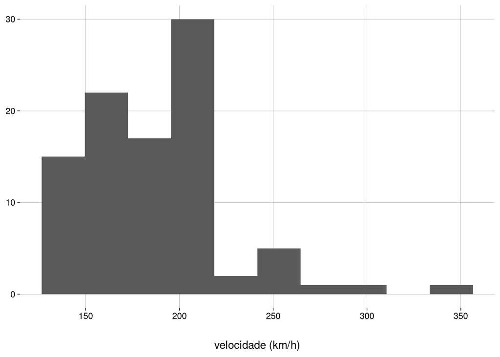

```r
df %>%
  histograma('velocidade', 10) +
  labs(
    y = NULL,
    x = 'velocidade (km/h)'
  )
```

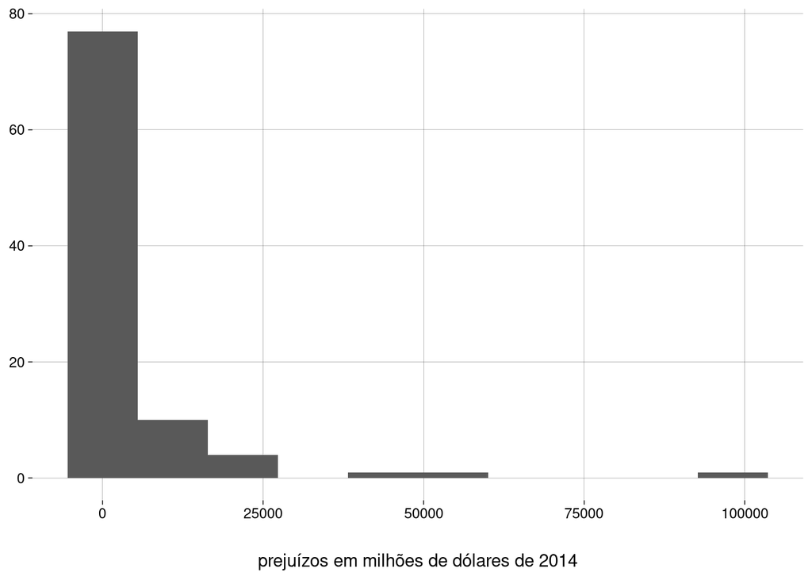

```r
df %>%
  histograma('prejuizo', 10) +
  labs(
    y = NULL,
    x = 'prejuízos em milhões de dólares de 2014'
  )
```

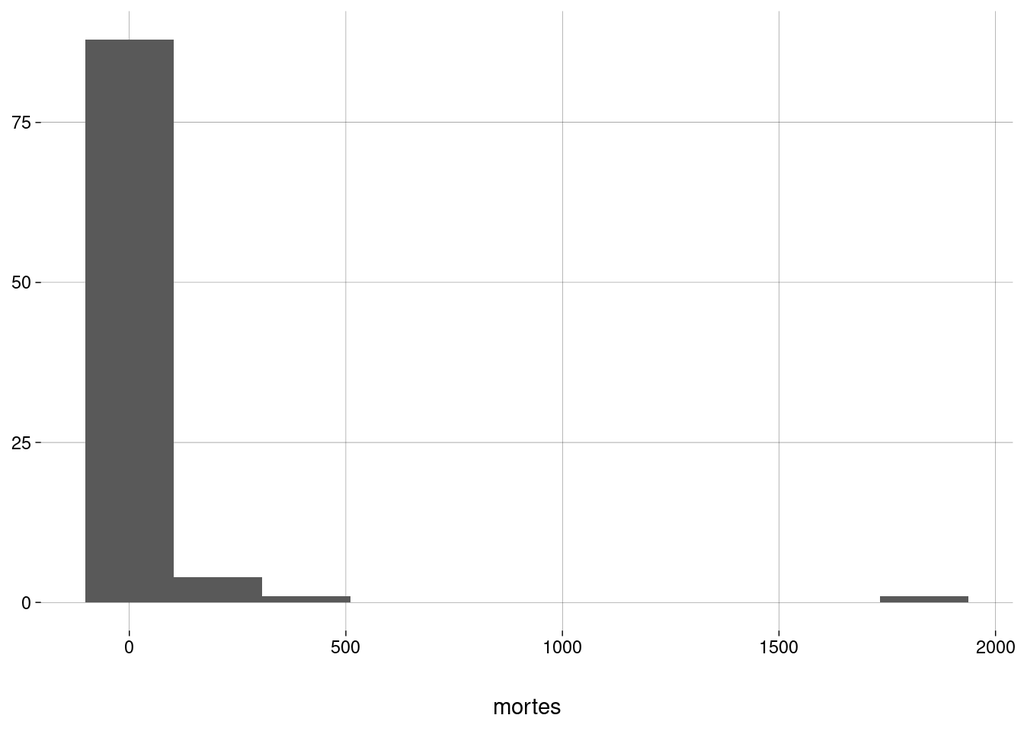

```r
df %>%
  histograma('mortes', 10) +
  labs(
    y = NULL,
    x = 'mortes'
  )
```

## 1.2 Histogramas transformados

Os histogramas de prejuízos e mortes não ficaram bons.

No *data frame*, crie duas novas colunas:

- `logprejuizo`: *logaritmo* do prejuízo (na base $10$)
- `logmortes`: *logaritmo* do número de mortes (na base $10$)

Agora, gere histogramas destas duas novas variáveis.

```r
df <- df %>%
  mutate(
    logprejuizo = log10(prejuizo),
    logmortes = log10(mortes)
  )
```

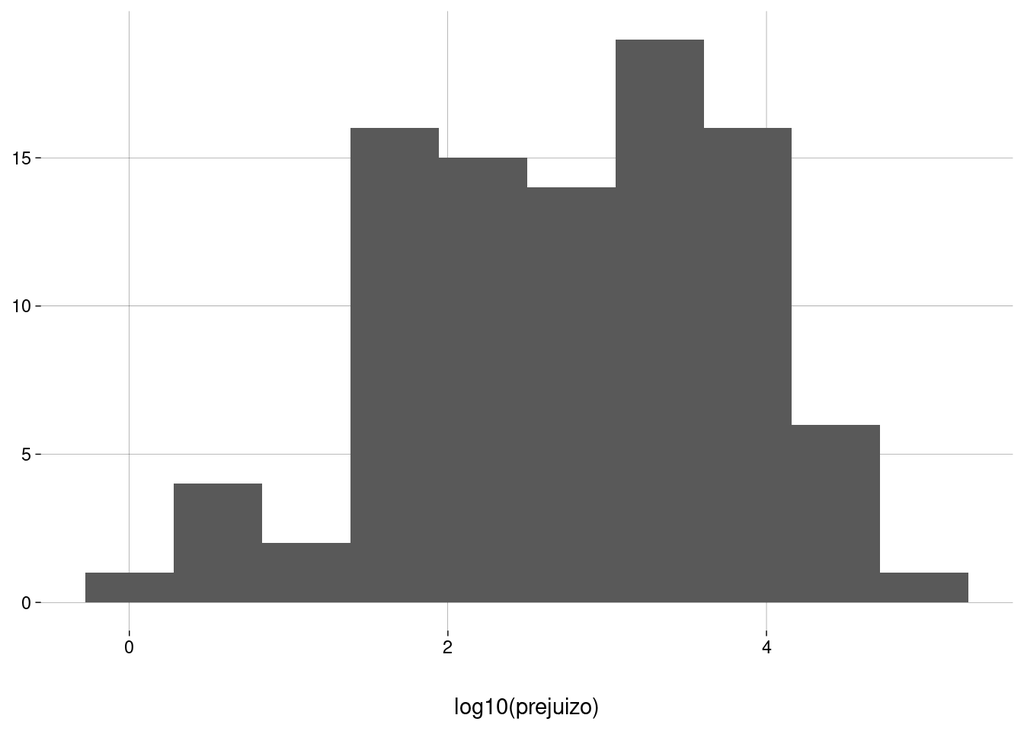

```r
df %>%
  histograma('logprejuizo', 10) +
  labs(
    y = NULL,
    x = 'log10(prejuizo)'
  )
```

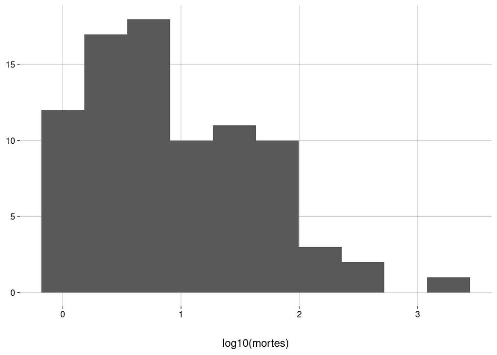

```r
df %>%
  histograma('logmortes', 10) +
  labs(
    y = NULL,
    x = 'log10(mortes)'
  )
```

## 1.3 Significado dos logaritmos

- O que significa o valor do logaritmo do prejuízo na base $10$?

  $$\begin{align*}
  \log_{10} \;\; 10 &= 1 \\
  \log_{10} \;\; 500 &\approx 2{,}70 \\
  \log_{10} \;\; 1.000 &= 3 \\
  \log_{10} \;\; 50.000 &\approx 4{,}70 \\
  \log_{10} \;\; 100.000 &= 5
  \end{align*}$$

  Ou seja, aproximadamente a quantidade de dígitos do valor do prejuízo.
- O que significa o valor do logaritmo do número de mortes na base $10$?

  Aproximadamente a quantidade de dígitos do número de mortes.
- Por que o histograma do logaritmo do número de mortes vem com uma mensagem de aviso?

  Porque houve furacões com zero mortes, e $\log 0$ não é definido.
- Por que isto não acontece com o logaritmo do prejuízo?

  Porque não houve furacão com prejuízo zero:

  ```r
  df %>% filter(prejuizo == 0)
  ```

  | id | nome | ano | velocidade | pressao | prejuizo | mortes | genero | logprejuizo | logmortes |
  | --- | --- | --- | --- | --- | --- | --- | --- | --- | --- |

## 1.4 *Boxplots* de mortes

De agora em diante, ignore os furacões que não tiveram mortes.

Construa um *boxplot* dos logaritmos das quantidades de mortes.

Existem *outliers*? Descubra quais são eles e elimine-os do *data frame*.

```r
df <- df %>%
  filter(mortes > 0)
```

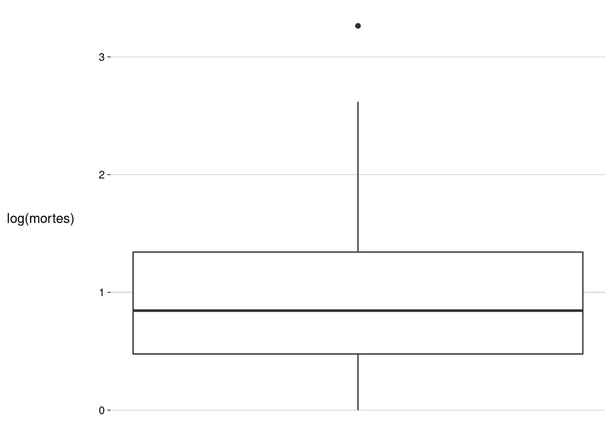

```r
df %>%
  ggplot(aes(y = logmortes)) +
    geom_boxplot() +
    labs(
      y = 'log(mortes)'
    ) +
    scale_x_continuous(breaks = NULL)
```

```r
is_outlier <- function(x) {

  # Decidi incluir a mediana só para quartil[3] ser o terceiro quartil
  quartil <- quantile(x, c(.25, .5, .75))
  margem <- IQR(x) * 1.5

  limite_inf <- quartil[1] - margem
  limite_sup <- quartil[3] + margem

  x < limite_inf | x > limite_sup

}
```

```r
df %>%
  filter(is_outlier(logmortes))
```

| id | nome | ano | velocidade | pressao | prejuizo | mortes | genero | logprejuizo | logmortes |
| --- | --- | --- | --- | --- | --- | --- | --- | --- | --- |
| 2005-Katrina | Katrina | 2005 | 225 | 920 | 98195 | 1836 | f | 4,992089 | 3,263873 |

```r
df <- df %>%
  filter(!is_outlier(logmortes))
```

## 1.5 *Boxplots* de mortes por gênero do furacão

Certifique-se de ter eliminado os *outliers* da questão anterior.

Construa dois *boxplots*, lado a lado, dos logaritmos das quantidades de mortes, cada *boxplot* correspondendo a um gênero. Use cores diferentes para os gêneros.

Comente.

Além dos *boxplots*, decidi sobrepor os pontos individuais:

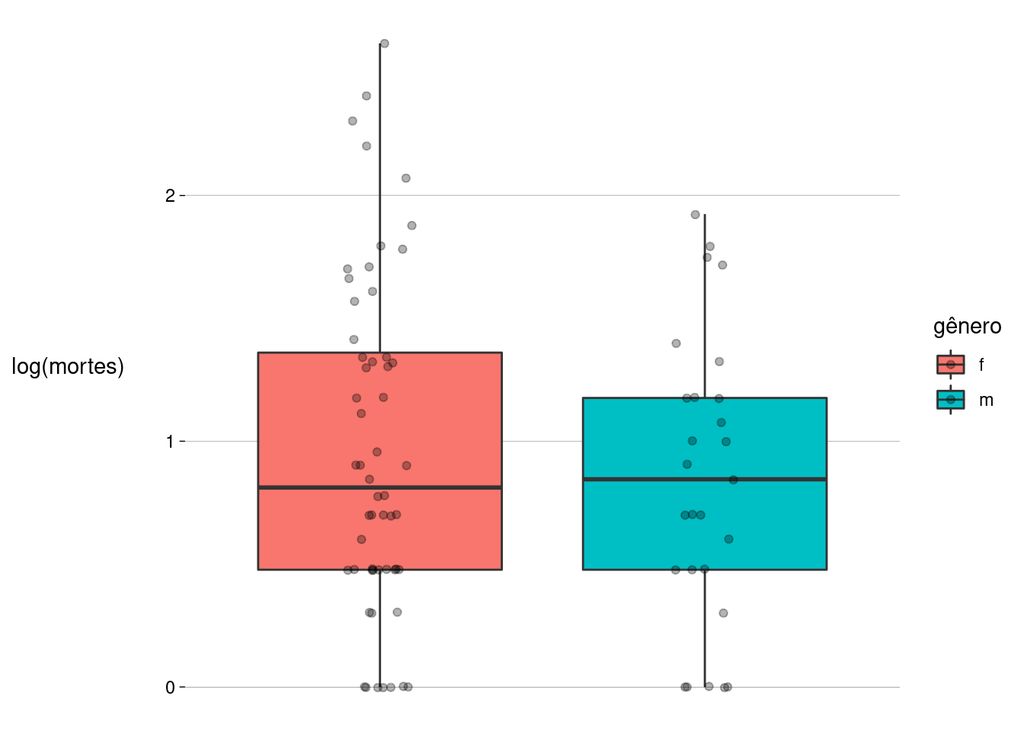

```r
df %>%
  ggplot(aes(x = genero, y = logmortes, fill = genero)) +
    geom_boxplot() +
    labs(
      x = NULL,
      y = 'log(mortes)',
      fill = 'gênero'
    ) +
    scale_x_discrete(breaks = NULL) +
    geom_jitter(width = .1, alpha = .3)
```

A variação é maior para furacões com nome de mulher.

Existem quantidade maior de mortes para alguns ($5$) furacões com nome de mulher.

As medianas e primeiros quartis são bem parecidos entre furacões homens e furacões mulheres.

## 1.6 *Scatterplot* de pressão por velocidade

Faça um gráfico de dispersão com `pressao` no eixo $y$ e `velocidade` no eixo $x$.

Usando `geom_smooth`, sobreponha uma reta de regressão ao gráfico.

O que você observa?

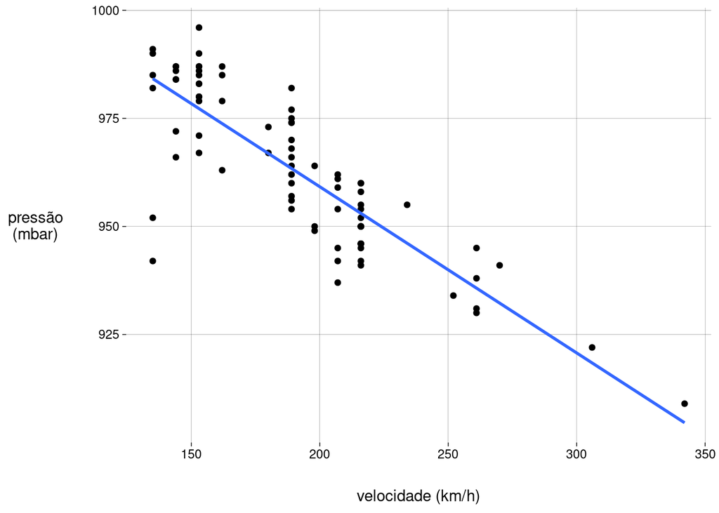

```r
df %>%
  ggplot(aes(velocidade, pressao)) +
    geom_point() +
    geom_smooth(method = 'lm', se = FALSE, formula = y ~ x) +
    labs(
      x = 'velocidade (km/h)',
      y = 'pressão\n(mbar)'
    )
```

À medida que a velocidade aumenta, a pressão diminui.

A relação é aproximadamente linear.

## 1.7 *Scatterplot* de log(mortes) por pressão

Faça um gráfico de dispersão com `logmortes` no eixo $y$ e `pressao` no eixo $x$.

Usando `geom_smooth`, sobreponha uma reta de regressão ao gráfico.

O que você observa?

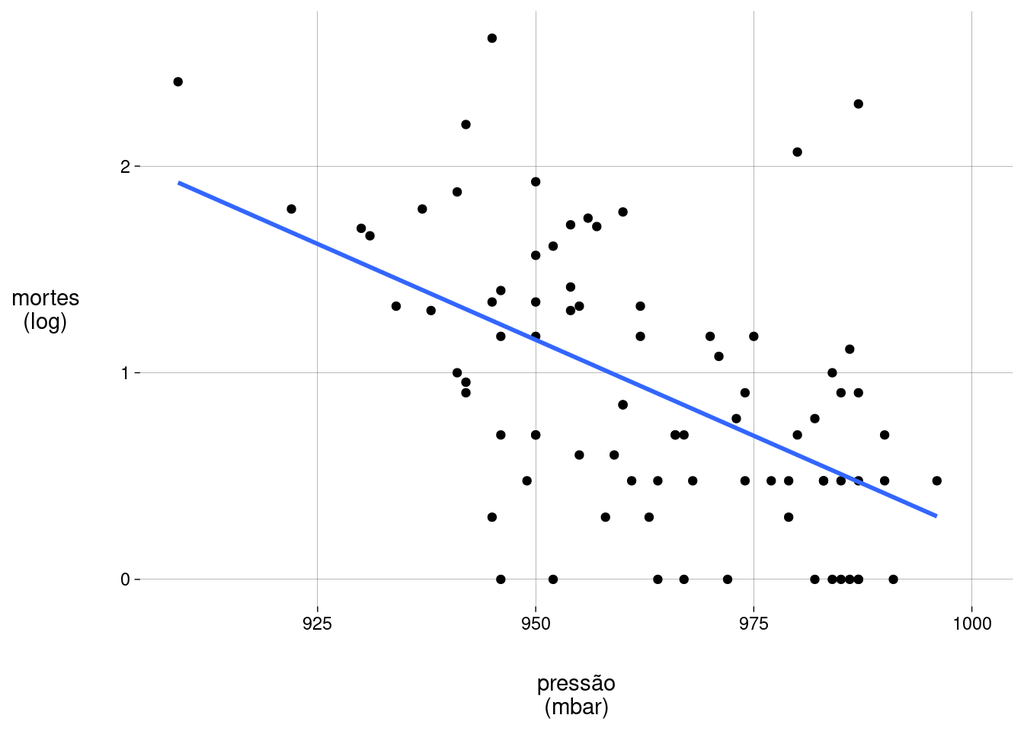

```r
df %>%
  ggplot(aes(pressao, logmortes)) +
    geom_point() +
    geom_smooth(method = 'lm', se = FALSE, formula = y ~ x) +
    labs(
      x = 'pressão\n(mbar)',
      y = 'mortes\n(log)'
    ) +
    scale_x_continuous(expand = expansion(mult = c(.05, .1)))
```

Quanto maior a pressão, menor o valor de $\log_{10}\; \text{mortes}$.

A relação é aproximadamente linear, mas a variabilidade é grande. Muitos pontos estão bem distantes da reta.

## 1.8 *Scatterplot* de log(mortes) por pressão, por gênero do furacão

Faça um gráfico de dispersão com `logmortes` no eixo $y$ e `pressao` no eixo $x$, com pontos coloridos de acordo com o gênero do nome do furacão.

Usando `geom_smooth`, sobreponha retas de regressão ao gráfico.

O que você observa?

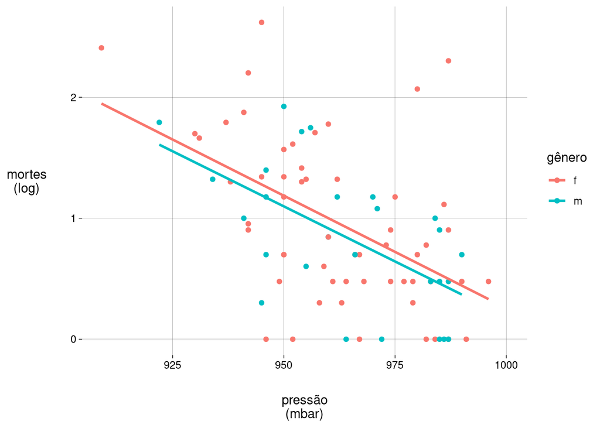

```r
df %>%
  ggplot(aes(pressao, logmortes, color = genero)) +
    geom_point() +
    geom_smooth(method = 'lm', se = FALSE, formula = y ~ x) +
    labs(
      x = 'pressão\n(mbar)',
      y = 'mortes\n(log)',
      color = 'gênero'
    ) +
    scale_x_continuous(expand = expansion(mult = c(.05, .1)))
```

Para uma mesma pressão, o valor de $\log_{10}\; \text{mortes}$ foi um pouco maior para furacões com nome de mulher do que para furacões com nome de homem.

Para saber se a diferença é significativa, precisamos fazer um teste estatístico. Isto vai ser assunto de uma aula futura, sobre regressão múltipla.

# 2 Adivinhando uma carta

Uma carta é escolhida ao acaso de um baralho de $52$ cartas.

Seu objetivo é adivinhar qual é a carta escolhida.

1. Se você adivinhar ao acaso, qual é a sua chance de acertar?

   $\frac{1}{52} = 0{,}02$
2. Imagine que, antes de tentar adivinhar, você pode fazer uma pergunta do tipo sim ou não.

   Qual das seguintes perguntas maximiza a probabilidade de você acertar (i.e., a probabilidade calculada *antes* de você fazer a pergunta)?
   1. A carta é vermelha?

      Como queremos calcular a probabilidade de acertar *antes* de fazer a pergunta, precisamos saber:
      - A probabilidade de a carta ser vermelha E você adivinhar a carta vermelha certa.

        $$\frac12 \cdot \frac{1}{26} \quad=\quad
        \frac1{52} \quad=\quad
        0{,}02$$
      - A probabilidade de a carta NÃO ser vermelha E você adivinhar a carta não-vermelha certa.

        $$\frac12 \cdot \frac{1}{26} \quad=\quad
        \frac1{52} \quad=\quad
        0{,}02$$
      - A probabilidade total é obtida somando as probabilidades dos dois casos:

        $$\frac1{52} + \frac1{52} \quad=\quad
        \frac{2}{52} \quad=\quad
        0{,}04$$
   2. A carta é de figura (i.e., valete, dama ou rei)?

      Como queremos calcular a probabilidade de acertar *antes* de fazer a pergunta, precisamos saber:
      - A probabilidade de a carta ser de figura E você adivinhar a carta de figura certa.

        $$\frac{12}{52} \cdot \frac{1}{12} \quad=\quad
        0{,}02$$
      - A probabilidade de a carta NÃO ser de figura E você adivinhar a carta não-figura certa.

        $$\frac{40}{52} \cdot \frac{1}{40} \quad=\quad
        0{,}02$$
      - A probabilidade total é obtida somando as probabilidades dos dois casos:

        $$\frac{12}{52} \cdot \frac{1}{12} \;+\;
        \frac{40}{52} \cdot \frac{1}{40} \quad=\quad
        \frac{1}{52} + \frac{1}{52} \quad=\quad
        \frac{2}{52} \quad=\quad
        0{,}04$$
      - A mesma probabilidade que no item anterior!
   3. A carta é um ás?

      Como queremos calcular a probabilidade de acertar *antes* de fazer a pergunta, precisamos saber:
      - A probabilidade de a carta ser um ás E você adivinhar o ás certo.

        $$\frac{4}{52} \cdot \frac{1}{4} \quad=\quad
        0{,}02$$
      - A probabilidade de a carta NÃO ser um ás E você adivinhar a carta não-ás certa.

      Como queremos calcular a probabilidade de acertar *antes* de fazer a pergunta, precisamos saber:
      - A probabilidade de a carta ser o ás de espadas E você adivinhar — o que é certo.

        $$\frac{1}{52} \cdot \frac{1}{1} \quad=\quad
        0{,}02$$
      - A probabilidade de a carta NÃO ser o ás de espadas E você adivinhar a carta certa.

        $$\frac{51}{52} \cdot \frac{1}{51} \quad=\quad
        0{,}02$$
      - A probabilidade total é obtida somando as probabilidades dos dois casos:

        $$\frac{1}{52} \cdot \frac{1}{1} \;+\;
        \frac{51}{52} \cdot \frac{1}{51} \quad=\quad
        \frac{1}{52} + \frac{1}{52} \quad=\quad
        \frac{2}{52} \quad=\quad
        0{,}04$$
      - A mesma probabilidade que no item anterior!
      - O que está acontecendo aqui?
3. Explique em detalhes os cálculos de todas as probabilidades.

   Os cálculos estão explicados no item anterior.
4. Comente os resultados.

   Com uma pergunta do tipo sim ou não (desde que as duas respostas sejam possíveis), sempre temos uma probabilidade de acertar que é o dobro da probabilidade de acertar sem a pergunta.

   Isto é verdade *independentemente* da pergunta.

   A pergunta separa as cartas em dois grupos, um com $x$ cartas, outro com $(52 - x)$ cartas, com $x \neq 0$.

   Se a carta estiver no primeiro grupo, o que ocorre com probabilidade $\frac{x}{52}$, a probabilidade de acertarmos é de $\frac1x$. Logo, a probabilidade conjunta é de $\frac{x}{52} \cdot \frac1x = \frac{1}{52}$.

   Se a carta estiver no segundo grupo, o que ocorre com probabilidade $\frac{52 - x}{52}$, a probabilidade de acertarmos é de $\frac1{52-x}$. Logo, a probabilidade conjunta é de $\frac{52-x}{52} \cdot \frac1{52-x} = \frac{1}{52}$.

   Como estas alternativas são mutuamente exclusivas, a probabilidade total é a soma: $\frac{2}{52}$.

   Pense no que acontece se a pergunta for trivial (ou seja, tiver sempre resposta sim ou sempre resposta não). Por exemplo:
   - A carta é verde?
   - A carta está no conjunto $\{A, 2, 3, 4, 5, 6, 7, 8, 9, 10, J, Q, K\}$?

   Qual a probabilidade de acertar, neste caso?

# 3 COVID e vacina

Considere a tabela:

$$\begin{array}{|l|r|r|r|}
& \text{Vacinados} & \text{Não vacinados} & \text{Totais} \\
\hline
\text{Doentes} & 2 & 2 & 4 \\
\text{Sadios} & 16 & 0 & 16 \\
\hline
\text{Totais} & 18 & 2 & 20 \\
\hline
\end{array}$$

Vamos armazenar as informações em uma matriz:

```r
matriz <- matrix(
  c(2, 16, 2, 0),
  nrow = 2
) %>%
  addmargins()

dimnames(matriz) <-  list(
  c('doentes', 'sadios', 'total'),
  c('vacinados', 'não vacinados', 'total')
)

matriz
```

```
##         vacinados não vacinados total
## doentes         2             2     4
## sadios         16             0    16
## total          18             2    20
```

Agora podemos responder as perguntas abaixo usando esta tabela.

1. Qual a probabilidade de uma pessoa ter sido vacinada?

   É a proporção do total de vacinados em relação ao total de pessoas:

   ```r
   matriz['total', 'vacinados'] / matriz['total', 'total']
   ```

   ```
   ## [1] 0,9
   ```

2. Qual a probabilidade de uma pessoa vacinada ter ficado doente?

   É a probabilidade de uma pessoa ter ficado doente, *dado que* a pessoa foi vacinada.

   Em símbolos:

   $$P(\text{doente} \mid \text{vacinado}) =
   \frac{P(\text{doente} \cap \text{vacinado})}{P(\text{vacinado})}$$

   ```r
   doente_se_vacinado <-
     matriz['doentes', 'vacinados'] / matriz['total', 'vacinados']

   doente_se_vacinado
   ```

   ```
   ## [1] 0,1111111
   ```

3. Qual a probabilidade de uma pessoa não vacinada ter ficado doente?

   É a probabilidade de uma pessoa ter ficado doente, *dado que* a pessoa *não* foi vacinada.

   Em símbolos:

   $$P(\text{doente} \mid \text{não vacinado}) =
   \frac{P(\text{doente} \cap \text{não vacinado})}{P(\text{não vacinado})}$$

   ```r
   doente_se_nao_vacinado <-
     matriz['doentes', 'não vacinados'] / matriz['total', 'não vacinados']

   doente_se_nao_vacinado
   ```

   ```
   ## [1] 1
   ```

   Pessoas não vacinadas ficaram doentes com probabilidade de $100\%$. Olhando pela tabela, vemos que *todos* os não vacinados ficaram doentes.
4. Calcule a eficácia da vacina, dada por

   $$\frac{P(\text{doente} \mid \text{não vacinado}) - P(\text{doente} \mid \text{vacinado})}{P(\text{doente} \mid \text{não vacinado})}$$

   ```r
   (doente_se_nao_vacinado - doente_se_vacinado) / doente_se_nao_vacinado
   ```

   ```
   ## [1] 0,8888889
   ```

   A eficácia da vacina é de cerca de $89\%$.
5. Explique, em suas palavras, o cálculo da eficácia da vacina.

   Perceba que podemos escrever a eficácia como

   $$1 - \frac{P(\text{doente} \mid \text{vacinado})}{P(\text{doente} \mid \text{não vacinado})}$$

   Isto equivale a $100\%$ menos a razão entre
   - a proporção de doentes entre os vacinados e
   - a proporção de doentes entre os não vacinados.

   Quanto menos doentes entre os vacinados (em proporção), menor o numerador e maior a eficácia.

   Quanto menos doentes entre os não vacinados (em proporção), menor o denominador e menor a eficácia.

# 4 Probabilidades condicionais e complementos

Das igualdades abaixo, prove as que são verdadeiras e ache contra-exemplos para as que são falsas:

1. $P(A \mid B) + P(\overline A \mid \overline B) = 1$

   Falso.

   Imagine que lançamos um dado não viciado.

   Considere os eventos
   - $A = {}$ o resultado é $2$ ou $4$
   - $B = {}$ o resultado é par

   Então
   - $\overline A = {}$ o resultado não é $2$ nem $4$
   - $\overline B = {}$ o resultado é ímpar

   Daí,

   $$P(A \mid B) + P(\overline A \mid \overline B) = 2/3 + 1 \neq 1$$
2. $P(A \mid B) + P(A \mid \overline B) = 1$

   Falso.

   Imagine que lançamos um dado não viciado.

   Considere os mesmos eventos do item anterior.

   Então

   $$P(A \mid B) + P(A \mid \overline B) = 2/3 + 0 \neq 1$$
3. $P(A \mid B) + P(\overline A \mid B) = 1$

   Verdadeiro.

   $$\begin{align*}
   P(A \mid B) + P(\overline A \mid B)
   &= \frac{P(A \cap B)}{P(B)} + \frac{P(\overline A \cap B)}{P(B)} \\
   &= \frac{P(A \cap B) + P(\overline A \cap B)}{P(B)} \\
   &= \frac{P(B)}{P(B)} \\
   & = 1
   \end{align*}$$